# ITP-Shopify Store - Assignment 1 - Shopify Orientation and Admin Exploration

Author

Carmen Lia Jimenez Rodriguez

Published

June 24, 2026

# 1 Evidence of Shopify Learning Completion

The required Shopify Academy learning materials were completed, including:

- Introduction to Shopify
- Navigating the Shopify Admin
- Developing on Shopify
- Shopify Admin Guided Tour

# 2 Shopify Admin Exploration

## 2.1 Figure 1. Shopify Admin Dashboard

[figure not shown]

## 2.2 Figure 2. Introduction to Shopify Course Completion

[figure not shown]

## 2.3 Figure 3. Navigating the Shopify Admin Course Completion

[figure not shown]

## 2.4 Figure 4. Developing on Shopify Course Completion

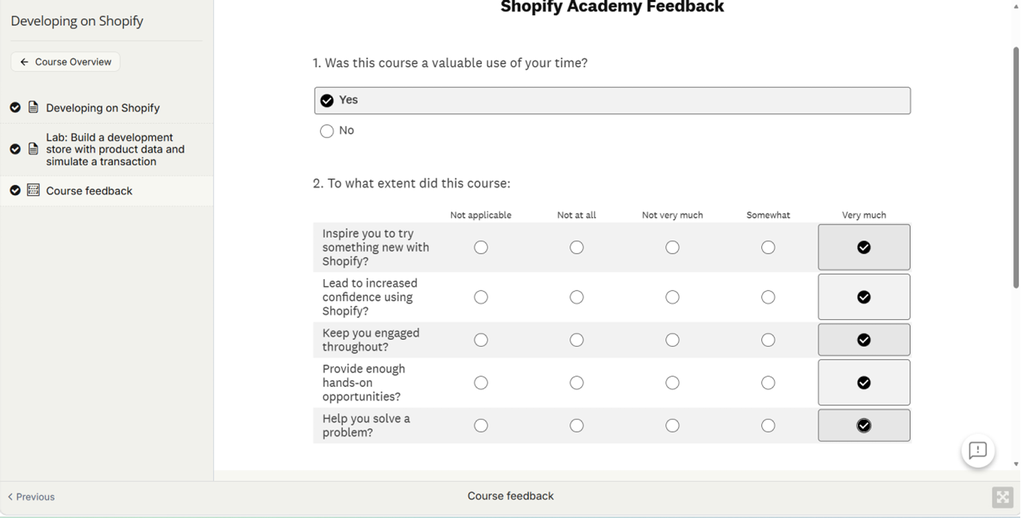

## 2.5 Figure 5. Shopify Admin Guided Tour

[figure not shown]

# 3 Important Shopify Features

## 3.1 Products

The Products section allows store owners to add new products, update product information, and organize their inventory. It serves as the main area for managing everything that will be available for customers to purchase.

## 3.2 Orders

The Orders feature helps businesses keep track of purchases made by customers. It allows users to monitor order status and manage the fulfillment process.

## 3.3 Customers

The Customers section stores customer information and helps businesses better understand their shoppers. It can be useful for building customer relationships and reviewing purchase history.

## 3.4 Analytics

The Analytics feature provides insights into store performance, including sales activity and customer trends. This information can help businesses make better decisions based on data.

## 3.5 Discounts

The Discounts section allows businesses to create promotions and special offers. These tools can help attract customers and encourage additional purchases.

# 4 CPP Farm Store Application Reflection

I think Shopify could be very helpful for the CPP Farm Store because it would give customers an easier way to learn about the products available and make purchases online. Not everyone has the opportunity to visit the store in person, so having an online platform could help the Farm Store reach more people and increase awareness of what it offers.

Shopify could also help organize products, keep track of inventory, and promote seasonal items such as fresh produce and other specialty products. Another benefit is that customers could stay updated on new products, promotions, and events without having to visit the store. Overall, I think Shopify would be a good tool for helping the CPP Farm Store grow its customer base while continuing to support local agriculture and the Cal Poly Pomona community.

# 5 Appendix

## 5.1 GitHub Repository

https://github.com/carmenjimenez97/Shopify_Assignment